# Week 5 Assignment

Oluwafemi Fabiyi

11/05/2020

### Loading relevant libraries

```r
# install.packages("readr")
# install.packages("tidyverse") # include magrittr
# install.packages("stringr")
# install.packages("lattice")
# install.packages("ggplot2")

library(readr)
library(tidyverse)
library(stringr)
library(lattice)
library(ggplot2)
```

```r
calcLog <-function(a, b){
  return (a*b+log(a))
}
```

###### 2) Create a function to check if the number is divisible by three or not

```r
divBy3 <- function(val){
  result <- FALSE
  if(val %% 3 == 0){
    result == 3
  }
  return (result)
}
```

###### 3) Create a list with the following 5 dataframes:

```r
Data1<-data.frame("State"=c("CA","NY","IL"),"Value"=c(900,1000,1200))
Data2<-data.frame("State"=c("MN","WI","IN"),"Value"=c(300,800,700))
Data3<-data.frame("State"=c("AZ","AR","TX"),"Value"=c(200,500,1300))
Data4<-data.frame("State"=c("MD","NJ","WA"),"Value"=c(400,1100,600))
Data5<-data.frame("State"=c("MA","NC","AL"),"Value"=c(100,1600,300))

myList <- list(Data1, Data2, Data3, Data4, Data5)
myList
```

```
## [[1]]
##   State Value
## 1    CA   900
## 2    NY  1000
## 3    IL  1200
##
## [[2]]
##   State Value
## 1    MN   300
## 2    WI   800
## 3    IN   700
##
## [[3]]
##   State Value
## 1    AZ   200
## 2    AR   500
## 3    TX  1300
##
## [[4]]
##   State Value
## 1    MD   400
## 2    NJ  1100
## 3    WA   600
##
## [[5]]
##   State Value
## 1    MA   100
## 2    NC  1600
## 3    AL   300
```

###### 4) Create a function using a for loop to stack the 5 Dataframes (add rows) in the list from questions 2:

```r
sizeOfOriginalList <- length(myList)
sizeOfOriginalList
```

```
## [1] 5
```

```r
for(i in 1:sizeOfOriginalList){
newIndex <- i + sizeOfOriginalList
myList[newIndex] <- myList[i]
}
myList
```

```
## [[1]]
##   State Value
## 1    CA   900
## 2    NY  1000
## 3    IL  1200
##
## [[2]]
##   State Value
## 1    MN   300
## 2    WI   800
## 3    IN   700
##
## [[3]]
##   State Value
## 1    AZ   200
## 2    AR   500
## 3    TX  1300
##
## [[4]]
##   State Value
## 1    MD   400
## 2    NJ  1100
## 3    WA   600
##
## [[5]]
##   State Value
## 1    MA   100
## 2    NC  1600
## 3    AL   300
##
## [[6]]
##   State Value
## 1    CA   900
## 2    NY  1000
## 3    IL  1200
##
## [[7]]
##   State Value
## 1    MN   300
## 2    WI   800
## 3    IN   700
##
## [[8]]
##   State Value
## 1    AZ   200
## 2    AR   500
## 3    TX  1300
##
## [[9]]
##   State Value
## 1    MD   400
## 2    NJ  1100
## 3    WA   600
##
## [[10]]
##   State Value
## 1    MA   100
## 2    NC  1600
## 3    AL   300
```

###### 5.1) GL Data Exploration (10 points)

Display the data structure and overview of the rows and columns of the dataset Use the summary method to display descriptive statistics for every variable

```r
dataPath <- "~/Desktop/MSc Analytics/Autumn 2020/MSCA 37010 2 - Programming for Analytics/Week 5/Assignment/"
dat <- read.csv(paste(dataPath,'GeneralLiabilityExposure.csv',sep = '/'), header=TRUE)
head(structure(dat))
```

```
##   PolicyLOB PolicyNumber PolicyEffectiveDate PolicyExpirationDate PolicyType
## 1   Package     X0000011          10/16/2007           10/15/2008        New
## 2   Package     X0000011          10/16/2007           10/15/2008        New
## 3   Package     X0000011          10/16/2007           10/15/2008        New
## 4   Package     X0000011          10/16/2007           10/15/2008        New
## 5   Package     X0000013          10/18/2007           10/17/2008    Renewal
## 6   Package     X0000013          10/18/2007           10/17/2008    Renewal
##          Segment ClassCode
## 1                       NA
## 2     Mercantile     59211
## 3 Rst/Bar/Tavern     16930
## 4 Rst/Bar/Tavern     16930
## 5                       NA
## 6     Mercantile     11127
##                                                                                                                                                         ClassCodeDescription
```

[output cut: 27 more lines]

```r
summary(dat)
```

```
##   PolicyLOB         PolicyNumber       PolicyEffectiveDate PolicyExpirationDate
##  Length:54370       Length:54370       Length:54370        Length:54370
##  Class :character   Class :character   Class :character    Class :character
##  Mode  :character   Mode  :character   Mode  :character    Mode  :character
##
##
##
##
##   PolicyType          Segment            ClassCode     ClassCodeDescription
##  Length:54370       Length:54370       Min.   :10042   Length:54370
##  Class :character   Class :character   1st Qu.:60010   Class :character
##  Mode  :character   Mode  :character   Median :61224   Mode  :character
##                                        Mean   :58424
##                                        3rd Qu.:63010
##                                        Max.   :99986
##                                        NA's   :6039
##  ClassCodeLOB         LocNumber       PremiumCategory         Rate
##  Length:54370       Min.   :  1.000   Length:54370       Min.   :   0.026
##  Class :character   1st Qu.:  1.000   Class :character   1st Qu.:  31.003
##  Mode  :character   Median :  1.000   Mode  :character   Median :  71.078
##                     Mean   :  6.051                      Mean   : 112.416
##                     3rd Qu.:  5.000                      3rd Qu.: 120.847
##                     Max.   :155.000                      Max.   :3500.000
##                     NA's   :7195                         NA's   :13568
##   RateModifier      AdjustedRate         Premium           Exposure
##  Min.   :  0.053   Min.   :   0.026   Min.   : -200.0   Min.   :       1
##  1st Qu.:  0.900   1st Qu.:  28.935   1st Qu.:  100.0   1st Qu.:       1
##  Median :  1.000   Median :  68.625   Median :  350.0   Median :       7
##  Mean   :  0.961   Mean   : 106.275   Mean   :  697.8   Mean   :   73450
##  3rd Qu.:  1.000   3rd Qu.: 113.051   3rd Qu.:  646.0   3rd Qu.:    8125
##  Max.   :200.000   Max.   :3500.000   Max.   :59622.0   Max.   :16300000
##  NA's   :13402     NA's   :13568                        NA's   :13402
##  RatingBasisDivisor RiskRatingBasis       State                Zip
##  Min.   :   1.0     Length:54370       Length:54370       Min.   : 1002
##  1st Qu.:   1.0     Class :character   Class :character   1st Qu.:33016
##  Median :   1.0     Mode  :character   Mode  :character   Median :36611
##  Mean   : 365.1                                           Mean   :51218
##  3rd Qu.:1000.0                                           3rd Qu.:75503
##  Max.   :1000.0                                           Max.   :98684
##  NA's   :13402                                            NA's   :7195
##  AddlCoverageType
##  Length:54370
##  Class :character
##  Mode  :character
##
##
##
##
```

###### 5.2) Create a Scatterplot for the Exposure column (5 points)

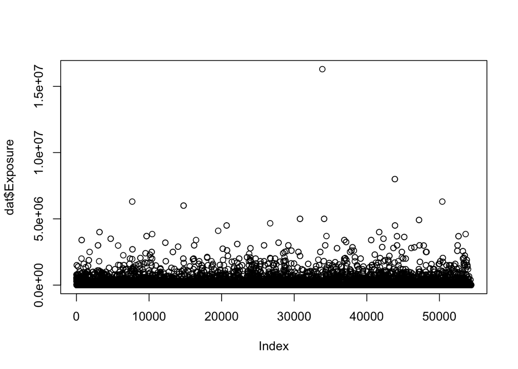

```r
plot(dat$Exposure)
```

###### 5.3) Create a Histogram of the Premium column using your favorite color (5 points)

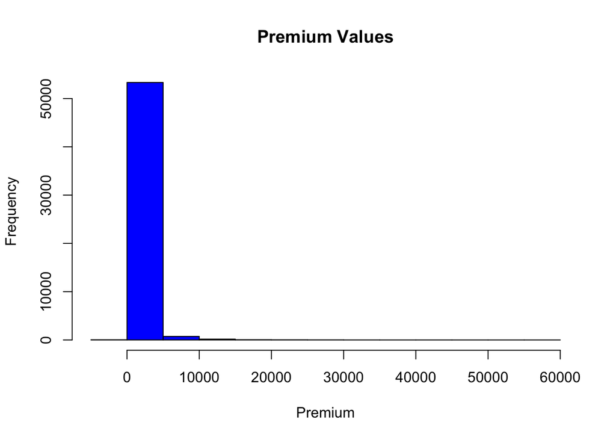

```r
hist(dat$Premium,
     main = 'Premium Values',xlab = 'Premium',
     col='blue')
```

###### 6.1 Use the ClaimSeverity column in the AutoCollision dataset to create a horizontal plot (5 points)

```r
dataPath <- "~/Desktop/MSc Analytics/Autumn 2020/MSCA 37010 2 - Programming for Analytics/Week 5/Assignment/"
mydat <- read.csv(paste(dataPath,'AutoCollision.csv',sep = '/'), header=TRUE)
head(structure(mydat))
```

```
##   AgeGroup VehicleUse ClaimSeverity ClaimCount
## 1 17 to 20   Pleasure        250.48         21
## 2 17 to 20 DriveShort        274.78         40
## 3 17 to 20  DriveLong        244.52         23
## 4 17 to 20   Business        797.80          5
## 5 21 to 24   Pleasure        213.71         63
## 6 21 to 24 DriveShort        298.60        171
```

```r
summary(mydat)
```

```
##    AgeGroup          VehicleUse        ClaimSeverity     ClaimCount
##  Length:32          Length:32          Min.   :153.6   Min.   :  5.0
##  Class :character   Class :character   1st Qu.:212.4   1st Qu.:116.2
##  Mode  :character   Mode  :character   Median :250.5   Median :208.0
##                                        Mean   :276.4   Mean   :279.4
##                                        3rd Qu.:298.2   3rd Qu.:366.0
##                                        Max.   :797.8   Max.   :970.0
```

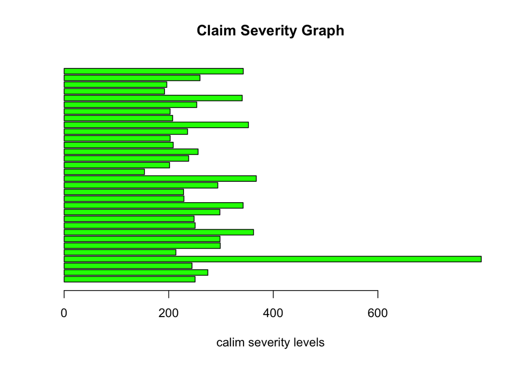

```r
barplot(mydat$ClaimSeverity,
        main = 'Claim Severity Graph',
        xlab = 'calim severity levels',
        col= 'green',horiz = TRUE)
```

###### 6.2) Use the ClaimSeverity column in the AutoCollision dataset to create a vertical plot (5 points)

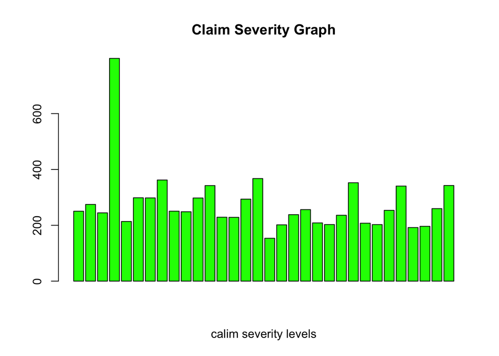

```r
barplot(mydat$ClaimSeverity,
        main = 'Claim Severity Graph',
        xlab = 'calim severity levels',
        col= 'green',horiz = FALSE)
```

###### 6.3) Use the ClaimCount column in the AutoCollision dataset to create a Single box plot (5 points)

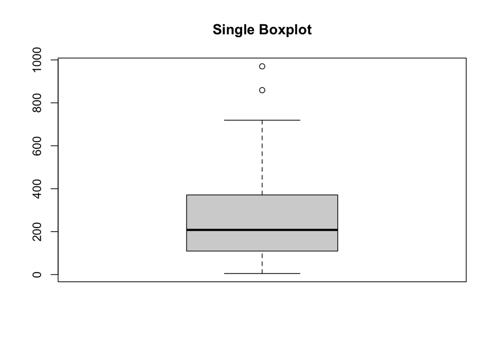

```r
#Single box plot
boxplot(mydat$ClaimCount, main='Single Boxplot')
```

###### 6.4) Use the 15-17 columns in the GL dataset to create a Multiple box plot (10 points)

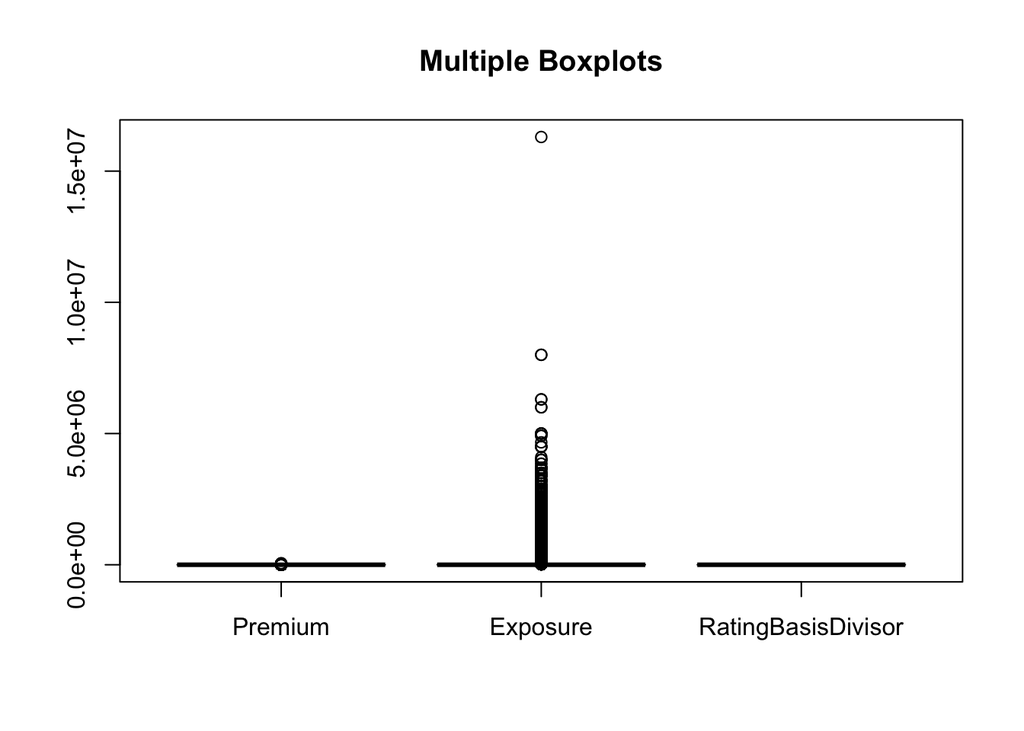

```r
# Multiple box plots
boxplot(dat[,15:17], main='Multiple Boxplots')
```

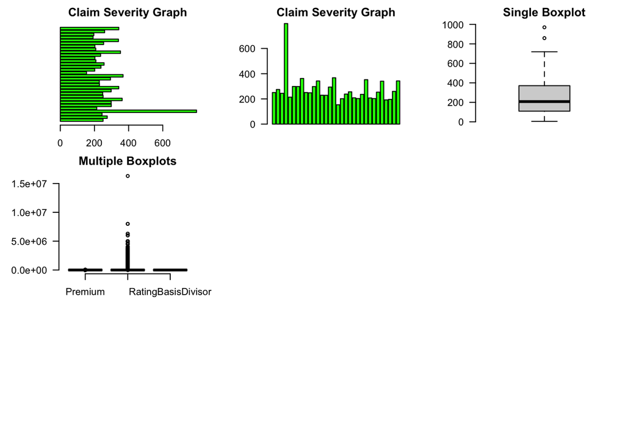

```r
par(mfrow=c(3,3), mar=c(2,5,2,1), las=1, bty="n")
barplot(mydat$ClaimSeverity,
        main = 'Claim Severity Graph',
        xlab = 'calim severity levels',
        col= 'green',horiz = TRUE)
barplot(mydat$ClaimSeverity,
        main = 'Claim Severity Graph',
        xlab = 'calim severity levels',
        col= 'green',horiz = FALSE)
boxplot(mydat$ClaimCount, main='Single Boxplot')
boxplot(dat[,15:17], main='Multiple Boxplots')
```

###### 7) Use the AutoCollision dataset to create a plot for each of ClaimSeverity and ClaimCount

columns arranged in a Scatterplot Matrix (Hint: use splom())

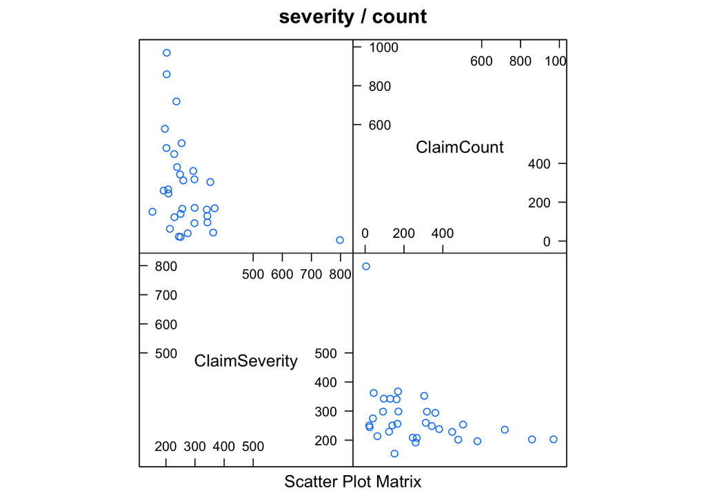

```r
splom(mydat[c(3,4)], main="severity / count")
```

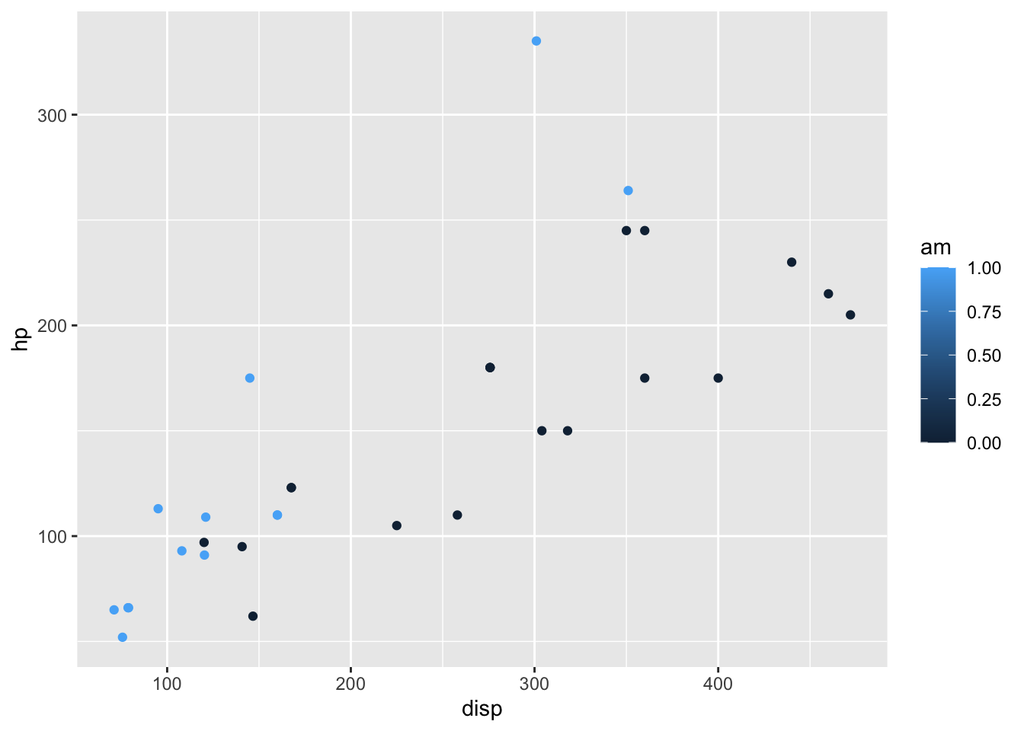

```r
library(ggplot2)
attach(mtcars)
palette("default")
cyl <- factor(cyl,levels=c(4,6,8),
              labels=c("4cyl","6cyl","8cyl"))
ggplot(data = mtcars, mapping = aes(x = disp, y = hp, color = am)) + geom_point()
```

###### 9.1) What is the function to remove object x?

```r
x <- c(1:3)
x
```

```
## [1] 1 2 3
```

```r
rm(x)
```

###### 9.2) What is the garbage collection function used to releases memory, freeing it up to used once again?

```r
 gc()
```

```
##           used (Mb) gc trigger  (Mb) limit (Mb) max used  (Mb)
## Ncells 1182886 63.2    2216512 118.4         NA  2216512 118.4
## Vcells 3110044 23.8    8388608  64.0      16384  8373347  63.9
```

###### 9.3) What function is used to check how much memory is being used?

```r
 memory.profile()
```

```
##        NULL      symbol    pairlist     closure environment     promise
##           1       23635      557492       10371        3882       23156
##    language     special     builtin        char     logical     integer
##      149605          45         692       49255       15684      101471
##      double     complex   character         ...         any        list
##        8872           6      144602          29           0       47260
##  expression    bytecode externalptr     weakref         raw          S4
##           2       38243        4352        1200        1218        1818
```